# Answer for LAQ1

````
``` r
#Take a look at a Scatter plot for single cells
files_Snu_P=list.files('C:/Users/dell/Downloads/AneuFinder/Snu119_parent/Aneufinder/MODELS/method-edivisive/', full.names=TRUE)
models_Snu_P = loadFromFiles(files_Snu_P)
plot(files_Snu_P[2], type='profile')
````

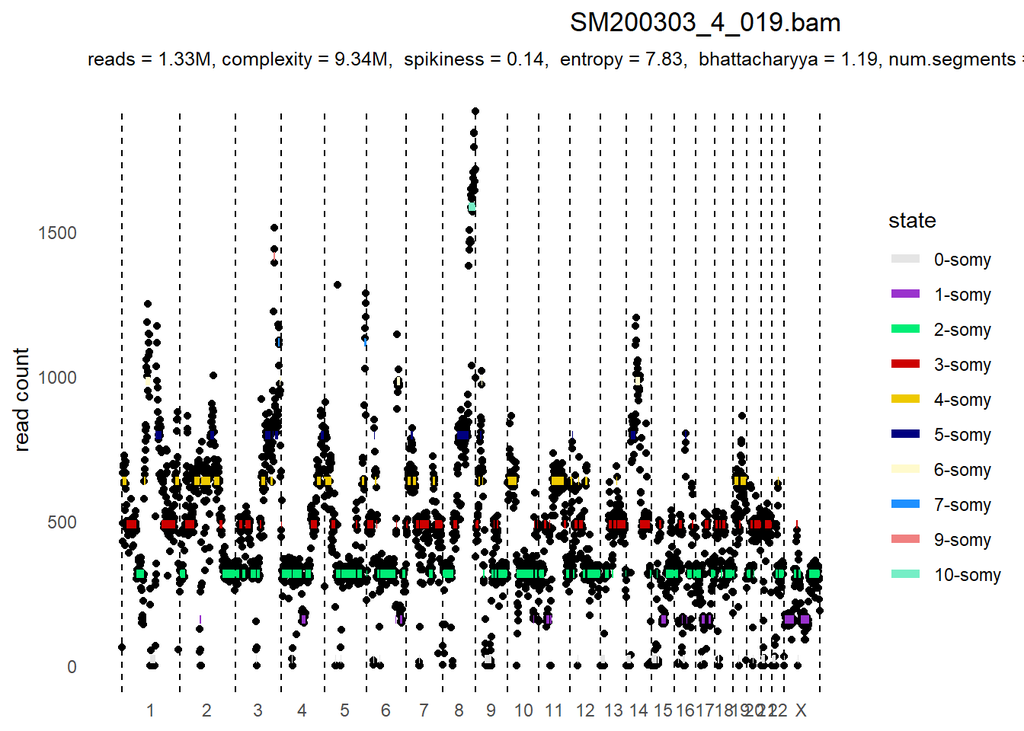

```r
#function to open CNV bedfiles
# Read file into a table, ensuring correct tab separation and filling missing values
Snu_P_data <- read.table(
  "C:/Users/dell/Downloads/AneuFinder/Snu119_parent/Aneufinder/BROWSERFILES/method-edivisive/binsize_1e+06_stepsize_1e+06_CNV.bed.gz",
  header = FALSE,
  sep = "\t",
  fill = TRUE,
  na.strings = ""
)

# Read the BED file line by line
lines_Snu_P <- readLines("C:/Users/dell/Downloads/AneuFinder/Snu119_parent/Aneufinder/BROWSERFILES/method-edivisive/binsize_1e+06_stepsize_1e+06_CNV.bed.gz")

# Initialize empty list for CNA records
Snu_P_records <- list()

# Define regex to extract cell_id from BAM file names
cell_id_pattern_Snu <- "SM[0-9_]+(?=\\.bam)"

# Initialize cell_id variable
cell_id_Snu <- NA

# Process each line
for (line in lines_Snu_P) {
    if (startsWith(line, "track")) {
        # Extract cell_id using regex
        match <- regexpr(cell_id_pattern_Snu, line, perl = TRUE)
        if (match > 0) {
            cell_id_Snu <- regmatches(line, match)
        }
    }
    # Check if the line contains CNA segment data
    else if (startsWith(line, "chr")) {
        # Split the line into values
        line_values_Snu <- unlist(strsplit(line, "\t"))

        # Ensure minimum required columns exist
        if (length(line_values_Snu) >= 5) {
            chrom_Snu <- line_values_Snu[1]
            start <- as.integer(line_values_Snu[2])
            end <- as.integer(line_values_Snu[3])
            copy_number_Snu <- as.integer(gsub("-somy", "", line_values_Snu[4]))

            # Handle color conversion (if column 9 exists)
            if (length(line_values_Snu) >= 9) {
                rgb_values_Snu <- as.integer(unlist(strsplit(line_values_Snu[9], ",")))
                if (length(rgb_values_Snu) == 3) {
                    color_Snu <- sprintf("#%02x%02x%02x", rgb_values_Snu[1], rgb_values_Snu[2], rgb_values_Snu[3])
                } else {
                    color_Snu <- NA
                }
            } else {
                color_Snu <- NA
            }

            # Append CNA segment to the list
            Snu_P_records <- append(Snu_P_records, list(data.frame(
                cell_id = cell_id_Snu,
                chrom = chrom_Snu,
                start = start,
                end = end,
                copy_number = copy_number_Snu,
                color = color_Snu,
                stringsAsFactors = FALSE
            )))
        }
    }
}

# Combine the list into a final dataframe
Snu_segments_df <- do.call(rbind, Snu_P_records)

# Return the dataframe
Snu_segments_df
```

```
##             cell_id chrom     start       end copy_number   color
## 1    SM200303_4_067  chr1         0  18000000           4 #eec900
## 2    SM200303_4_067  chr1  18000000  63000000           3 #cd0000
## 3    SM200303_4_067  chr1  63000000  95000000           2 #00ee76
## 4    SM200303_4_067  chr1  95000000 100000000           4 #eec900
## 5    SM200303_4_067  chr1 100000000 109000000           5 #000080
## 6    SM200303_4_067  chr1 109000000 120000000           8 #458b00
## 7    SM200303_4_067  chr1 120000000 122000000           2 #00ee76
## 8    SM200303_4_067  chr1 122000000 145000000           0 #e5e5e5
## 9    SM200303_4_067  chr1 145000000 168000000           5 #000080
## 10   SM200303_4_067  chr1 168000000 248000000           4 #eec900
## 11   SM200303_4_067  chr2         0  26000000           2 #00ee76
## 12   SM200303_4_067  chr2  26000000  91000000           4 #eec900
## 13   SM200303_4_067  chr2  91000000  94000000           0 #e5e5e5
## 14   SM200303_4_067  chr2  94000000 133000000           4 #eec900
```

[output cut: 2207 more lines]

```r
#load up r utilities so we can unzip the bed file from AneuFinder
library(R.utils)
Snu_P <- "C:/Users/dell/Downloads/AneuFinder/Snu119_parent/Aneufinder/BROWSERFILES/method-edivisive/binsize_1e+06_stepsize_1e+06_CNV.bed.gz"
#gunzip(Snu_P, remove = FALSE) # Set remove = TRUE to delete the .gz file after unzipping

# Load the gzipped BED file
filepath_Snu <- "C:/Users/dell/Downloads/AneuFinder/Snu119_parent/Aneufinder/BROWSERFILES/method-edivisive/binsize_1e+06_stepsize_1e+06_CNV.bed"
Snu_segments <- read.table(filepath_Snu, header = FALSE,
                                    sep = "",
                                    fill = TRUE, )

# View first few rows
head(Snu_segments)
```

```
##      V1        V2        V3     V4                  V5               V6
## 1 track name="CNV     state    for SM200303_4_067.bam" description="CNV
## 2  chr1         0  18000000 4-somy                   0                .
## 3  chr1  18000000  63000000 3-somy                   0                .
## 4  chr1  63000000  95000000 2-somy                   0                .
## 5  chr1  95000000 100000000 4-somy                   0                .
## 6  chr1 100000000 109000000 5-somy                   0                .
##          V7        V8                  V9          V10        V11         V12
## 1     state       for SM200303_4_067.bam" visibility=1 itemRgb=On priority=54
## 2         0  18000000           238,201,0
## 3  18000000  63000000             205,0,0
## 4  63000000  95000000           0,238,118
## 5  95000000 100000000           238,201,0
## 6 100000000 109000000             0,0,128
```

For LAQ1 part 3. Calculate the number of genomic breakpoints per cell and per chromosome from the AneuFinder browser CNV files

```r
# Add a new column to track breakpoints
Snu_segments_df <- Snu_segments_df %>%
  group_by(chrom) %>%
  arrange(start) %>%  # Ensure data is ordered by genomic position
  mutate(breakpoint = c(0, diff(copy_number) != 0))  # 1 if copy number changes, 0 otherwise
# Count breakpoints per chromosome
breakpoints_per_chromosome_6 <- Snu_segments_df %>%
  group_by(chrom) %>%
  summarise(total_breakpoints = sum(breakpoint))

# results
print(breakpoints_per_chromosome_6)
```

```
## # A tibble: 23 × 2
##    chrom total_breakpoints
##    <chr>             <dbl>
##  1 chr1                 53
##  2 chr10                31
##  3 chr11                35
##  4 chr12                27
##  5 chr13                13
##  6 chr14                22
##  7 chr15                14
##  8 chr16                23
##  9 chr17                20
## 10 chr18                22
## # ℹ 13 more rows
```

```r
# breakpoints per cell
Snu_segments_df <- Snu_segments_df %>%
  group_by(cell_id, chrom) %>%
  arrange(start) %>%
  mutate(breakpoint = c(0, diff(copy_number) != 0))  # Identify breakpoints

# Count breakpoints per cell
breakpoints_per_cell_6 <- Snu_segments_df %>%
  group_by(cell_id) %>%
  summarise(total_breakpoints = sum(breakpoint))

# results
print(breakpoints_per_cell_6)
```

```
## # A tibble: 13 × 2
##    cell_id        total_breakpoints
##    <chr>                      <dbl>
##  1 SM200303_4_007               153
##  2 SM200303_4_019               161
##  3 SM200303_4_032               154
##  4 SM200303_4_043               153
##  5 SM200303_4_044               147
##  6 SM200303_4_055               163
##  7 SM200303_4_056               141
##  8 SM200303_4_067               147
##  9 SM200303_4_068               153
## 10 SM200303_4_079               168
## 11 SM200303_4_080               148
## 12 SM200303_4_091                92
## 13 SM200303_4_092               142
```

Plot Breakpoints

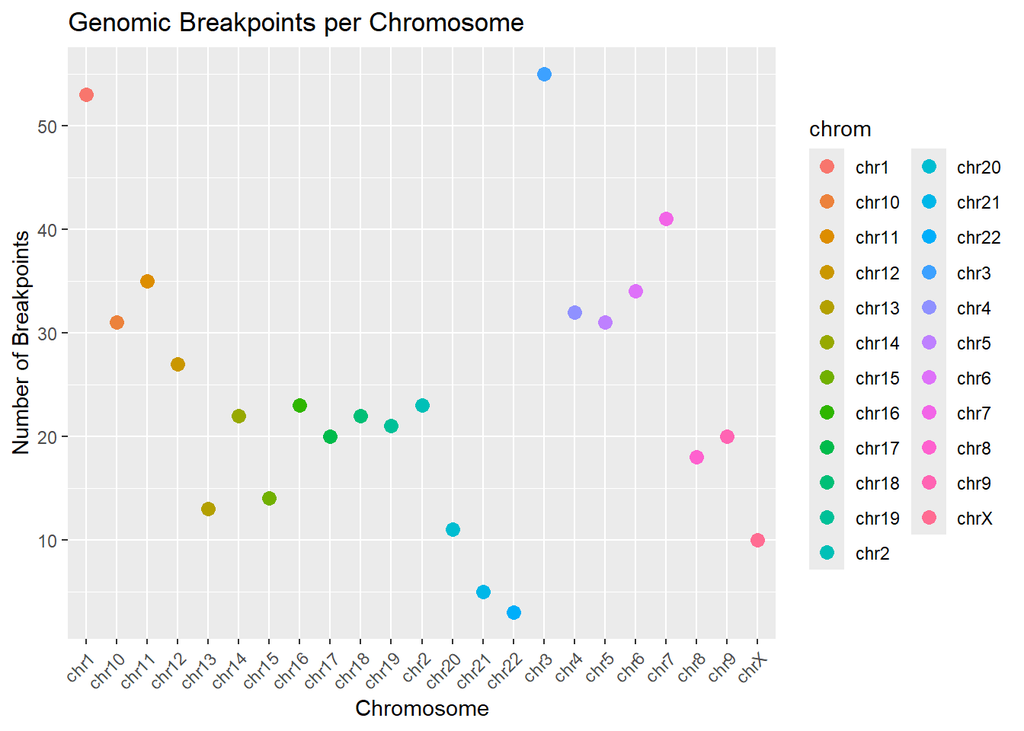

```r
#Per chromosome
ggplot(breakpoints_per_chromosome_6, aes(x = factor(chrom, levels = unique(chrom)), y = total_breakpoints, color = chrom)) +
  geom_point(size = 3) +
  theme(axis.text.x = element_text(angle = 45, hjust = 1)) +
  labs(title = "Genomic Breakpoints per Chromosome", x = "Chromosome", y = "Number of Breakpoints")
```

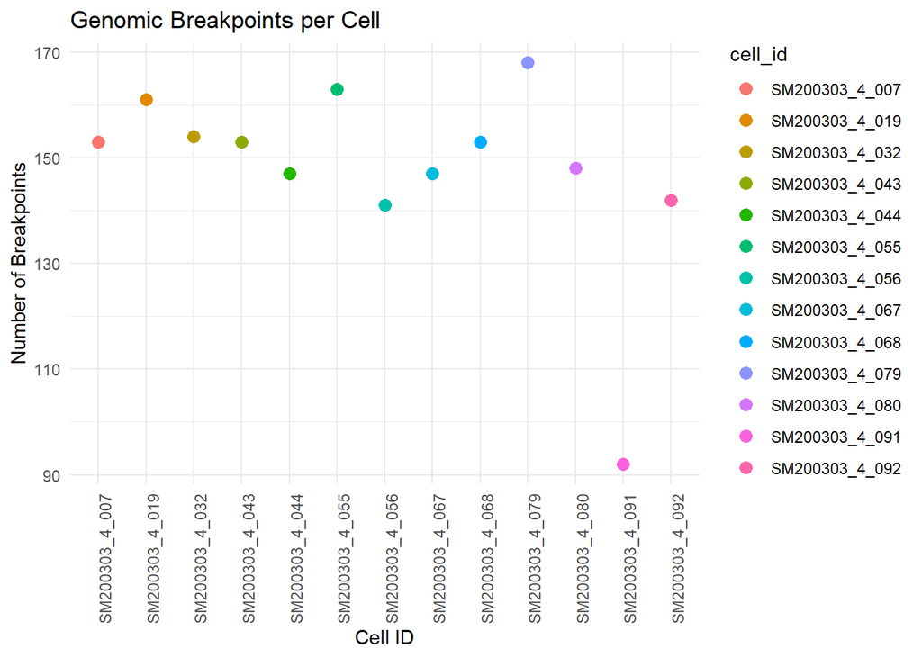

```r
# Per cell
ggplot(breakpoints_per_cell_6, aes(x = cell_id, y = total_breakpoints, color = cell_id)) +
  geom_point(size = 3) +
  theme_minimal() +
  labs(title = "Genomic Breakpoints per Cell", x = "Cell ID", y = "Number of Breakpoints") +
  theme(axis.text.x = element_text(angle = 90, hjust = 1))
```

**6) Snu_parent: LAQ 1- Part 3 (Are the CNVs distributed evenly across the chromosomes?):** No; The CNVs (represented by genomic breakpoints) are clearly not evenly distributed across the chromosomes:

for LAQ 1 part 4 - Alterations can be found across the two HGSOC cell lines and clones

```
## finding most frequent state for each sample and chromosome ... 4.97s
```

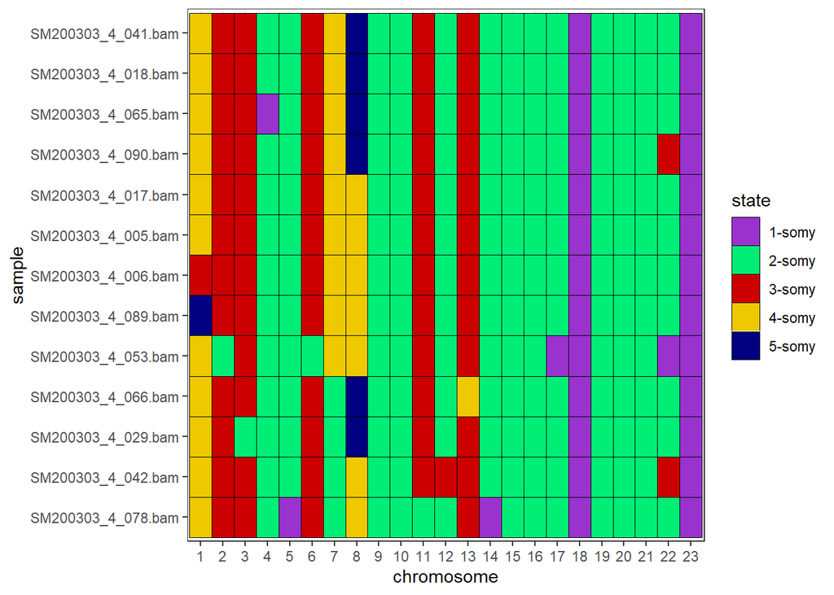

```r
heatmapAneuploidies(models_E10)
```

```
## finding most frequent state for each sample and chromosome ... 3s
```

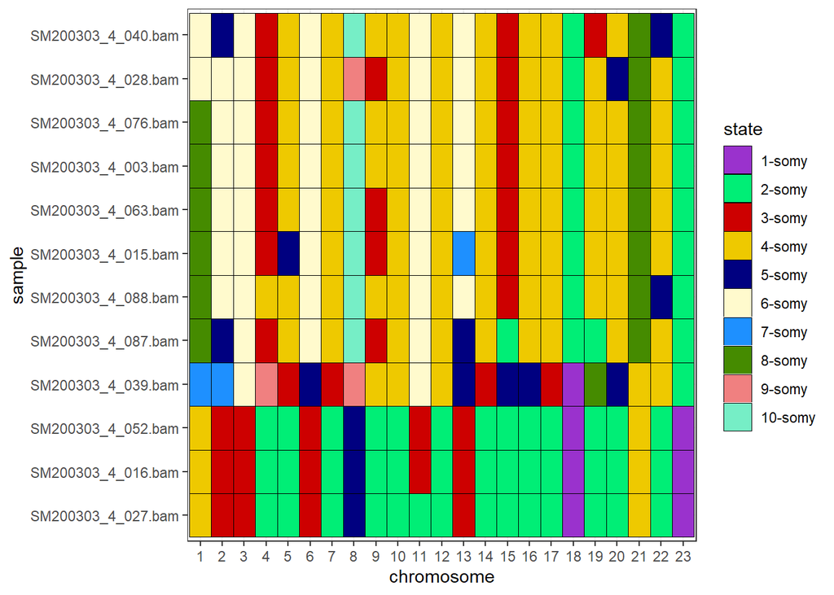

```r
heatmapAneuploidies(models_C8)
```

```
## finding most frequent state for each sample and chromosome ... 3.31s
```

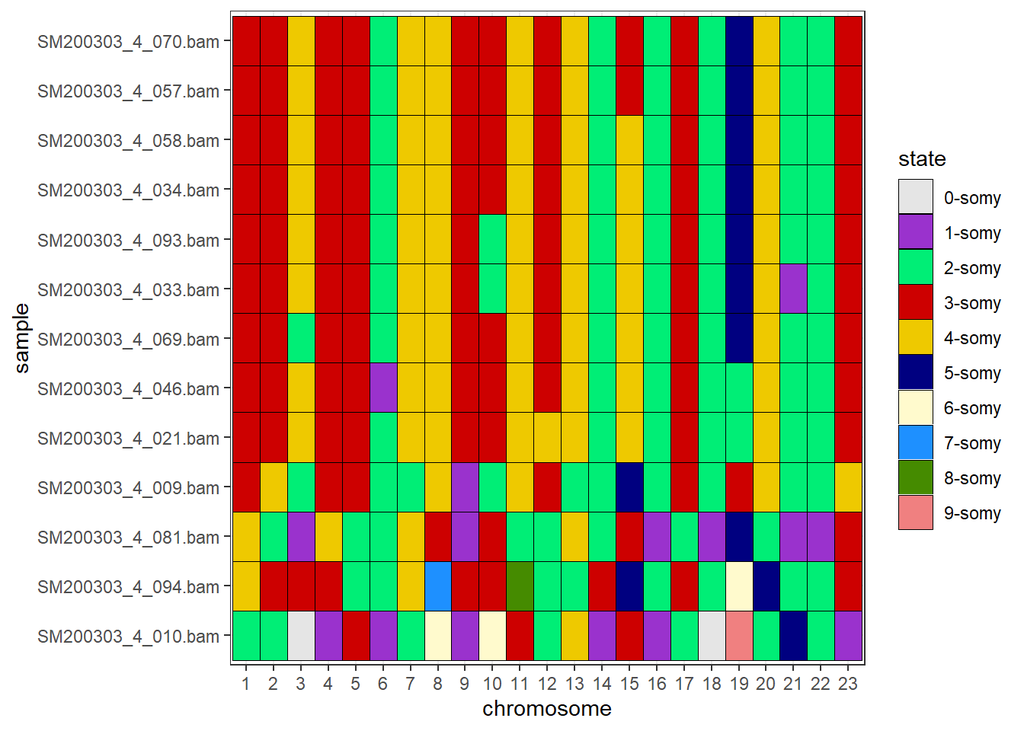

```r
heatmapAneuploidies(models_A12)
```

```
## finding most frequent state for each sample and chromosome ... 3.75s
```

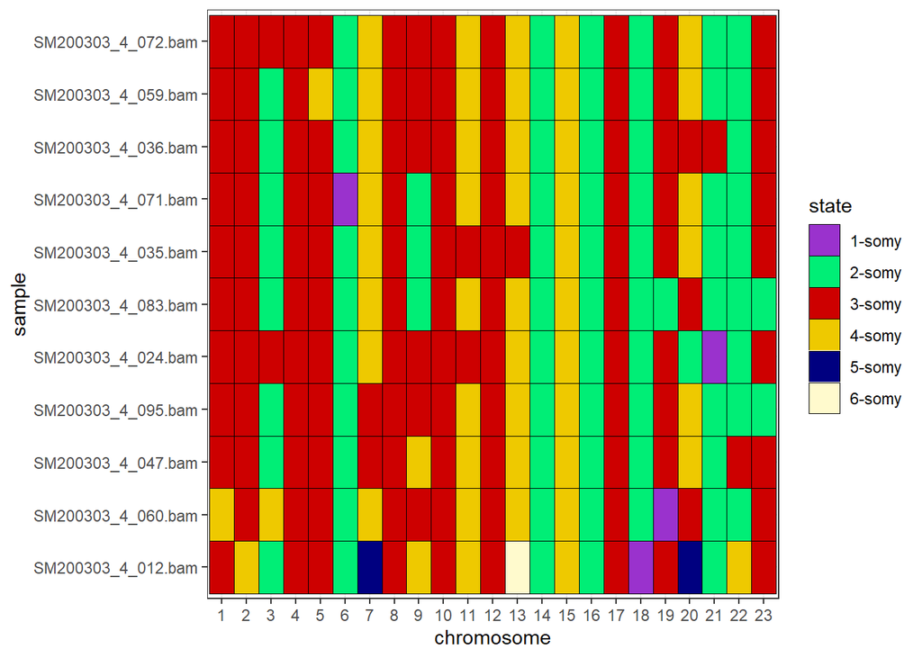

```r
heatmapAneuploidies(models_F12)
```

**From the different heatmaps for Kuramochi and Snu119 clones , here’s how we can interpret data for any alterations**

1. The x-axis represents chromosomes (1 to 23).
2. The y-axis represents different samples (likely from HGSOC cell lines and clones).
3. The colors indicate copy number states (ploidy changes): Purple (1-somy) → Loss of one copy (monosomy). Green (2-somy) → Normal diploid state. Red (3-somy) → Gain of one copy (trisomy). Yellow (4-somy) → Gain of two copies (tetrasomy). Blue (5-somy) → Higher-level amplification (pentasomy).

*Kuramochi Cell Line:* - Kuramochi_C8 shows a significantly higher frequency of chromosomes with increased copy numbers (4-somy, 6-somy, even up to 10-somy), highlighting substantial chromosomal amplification. - Kuramochi_E10 mostly shows lower-level alterations such as trisomy and tetrasomy, with fewer instances of extreme amplification.

*Snu119 Cell Line:* - Snu119_A12 and Snu119_F12 show consistent widespread trisomy and tetrasomy across many chromosomes, indicating significant chromosomal instability. - The parental line (Snu119_parent) also has frequent trisomy and tetrasomy, highlighting inherited instability in derived clones.

LAQ 1 part 5

5. MEDICC2 Kuramochi v/s Parent

```r
#Read branch lengths results Kuramochi
Kuramochi_branch_lengths <- read.table("C:/Users/dell/Downloads/Medicc2/medicc_output/mcs_Kuramochi_1000kb_branch_lengths.tsv", header = TRUE)
print(Kuramochi_branch_lengths)
```

```
##               internal20 X73.0
## 1             internal22     8
## 2             internal32     6
## 3             internal35     4
## 4             internal36     3
## 5             internal25     4
## 6     E10_SM200303_4_041    14
## 7     E10_SM200303_4_066    17
## 8             internal34     2
## 9     E10_SM200303_4_053    29
## 10            internal33     3
## 11            internal30     6
## 12    E10_SM200303_4_065    20
## 13    E10_SM200303_4_089    19
## 14            internal31     5
```

[output cut: 58 more lines]

```r
# remove the inferred internals
Kuramochi_branch_lengths <- Kuramochi_branch_lengths[-grep("internal", Kuramochi_branch_lengths$internal20), ]
print(Kuramochi_branch_lengths)
```

```
##               internal20 X73.0
## 6     E10_SM200303_4_041    14
## 7     E10_SM200303_4_066    17
## 9     E10_SM200303_4_053    29
## 12    E10_SM200303_4_065    20
## 13    E10_SM200303_4_089    19
## 17    E10_SM200303_4_005    16
## 18    E10_SM200303_4_018    10
## 20    E10_SM200303_4_090    15
## 21 parent_SM200303_4_050    12
## 24    E10_SM200303_4_042    29
## 25    E10_SM200303_4_078    17
## 27    E10_SM200303_4_006    15
## 28    E10_SM200303_4_029    12
## 29    E10_SM200303_4_017    39
```

[output cut: 23 more lines]

```r
# Assign new column names
colnames(Kuramochi_branch_lengths) <- c("Sample_ID", "Branch_Length")
print(Kuramochi_branch_lengths)
```

```
##                Sample_ID Branch_Length
## 6     E10_SM200303_4_041            14
## 7     E10_SM200303_4_066            17
## 9     E10_SM200303_4_053            29
## 12    E10_SM200303_4_065            20
## 13    E10_SM200303_4_089            19
## 17    E10_SM200303_4_005            16
## 18    E10_SM200303_4_018            10
## 20    E10_SM200303_4_090            15
## 21 parent_SM200303_4_050            12
## 24    E10_SM200303_4_042            29
## 25    E10_SM200303_4_078            17
## 27    E10_SM200303_4_006            15
## 28    E10_SM200303_4_029            12
## 29    E10_SM200303_4_017            39
```

[output cut: 23 more lines]

```r
# Create a new column to indicate the group (clone or parental) based on Sample_ID pattern
Kuramochi_branch_lengths <- Kuramochi_branch_lengths %>%
  mutate(Group = case_when(
    grepl("^parent", Sample_ID) ~ "Parent",
    grepl("^E10", Sample_ID) ~ "E10",
    grepl("^C8", Sample_ID) ~ "C8",
    TRUE ~ "Other"
  ))
# Set the Group column as a factor with the desired order
Kuramochi_branch_lengths <- Kuramochi_branch_lengths %>%
  mutate(Group = factor(Group, levels = c("Parent", "C8", "E10", "Other")))

# Arrange the data frame by the Group column
Kuramochi_branch_lengths <- Kuramochi_branch_lengths %>%
 arrange(Group)

# Print the ordered data frame
print(Kuramochi_branch_lengths)
```

```
##                Sample_ID Branch_Length  Group
## 1  parent_SM200303_4_050            12 Parent
## 2  parent_SM200303_4_014            17 Parent
## 3  parent_SM200303_4_001            16 Parent
## 4  parent_SM200303_4_062            19 Parent
## 5  parent_SM200303_4_002            19 Parent
## 6  parent_SM200303_4_037            20 Parent
## 7  parent_SM200303_4_049            15 Parent
## 8  parent_SM200303_4_073            14 Parent
## 9  parent_SM200303_4_086            13 Parent
## 10 parent_SM200303_4_026             4 Parent
## 11 parent_SM200303_4_061            24 Parent
## 12 parent_SM200303_4_013            16 Parent
## 13 parent_SM200303_4_038            14 Parent
## 14 parent_SM200303_4_085            20 Parent
```

[output cut: 23 more lines]

```r
# Summary statistics for each Group
summary_stats_Kura <- Kuramochi_branch_lengths %>%
  group_by(Group) %>%
  summarise(
    mean_branch_length = mean(Branch_Length),
    sd_branch_length = sd(Branch_Length)
  )
print(summary_stats_Kura)
```

```
## # A tibble: 3 × 3
##   Group  mean_branch_length sd_branch_length
##   <fct>               <dbl>            <dbl>
## 1 Parent               16.5             5.03
## 2 C8                   19.7             8.51
## 3 E10                  19.4             8.18
```

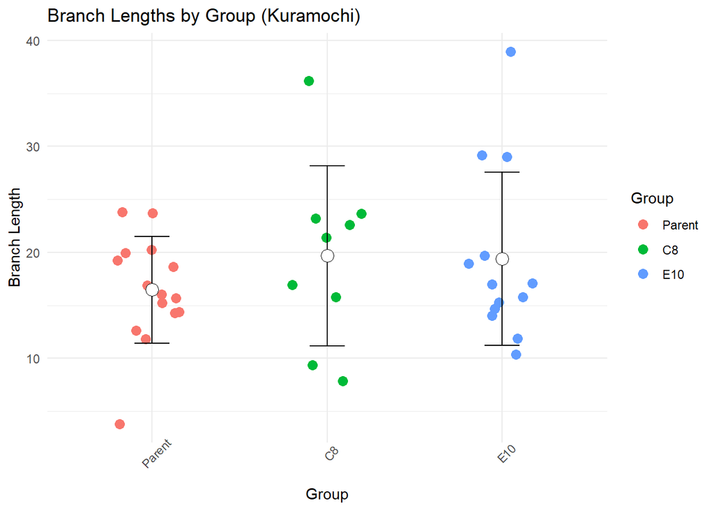

```r
# Scatter plot with jitter, error bars for SD, and mean points
ggplot(Kuramochi_branch_lengths, aes(x = Group, y = Branch_Length, color = Group)) +
  geom_jitter(width = 0.2, size = 3) +  # Jittered points
  # Error bars: Mean ± SD per group
  geom_errorbar(data = summary_stats_Kura,
                aes(x = Group, y = mean_branch_length,
                    ymin = mean_branch_length - sd_branch_length,
                    ymax = mean_branch_length + sd_branch_length),
                width = 0.2, color = "black") +
  # Add mean points
  geom_point(data = summary_stats_Kura, aes(x = Group, y = mean_branch_length),
             size = 4, shape = 21, fill = "white", color = "black") +
  theme_minimal() +
  labs(title = "Branch Lengths by Group (Kuramochi)",
       x = "Group",
       y = "Branch Length") +
  theme(axis.text.x = element_text(angle = 45))  # Rotate axis labels
```

**LAQ 1- Part 5: Snu199 v/s Parent (Most dissimilar clonal population to parental population):**

```r
#Read branch lengths results Snu119
Snu119_branch_lengths <- read.table("C:/Users/dell/Downloads/Medicc2/medicc_output/mcs_Snu119_all_1000kb_branch_lengths.tsv", header = TRUE)
print(Snu119_branch_lengths)
```

```
##               internal14 X36.0
## 1             internal15    23
## 2             internal16    14
## 3             internal28    23
## 4             internal32     2
## 5             internal33     6
## 6             internal35     7
## 7             internal37     9
## 8     F12_SM200303_4_047    31
## 9             internal36     3
## 10    F12_SM200303_4_024    24
## 11            internal30     9
## 12            internal24     4
## 13    A12_SM200303_4_058    19
## 14            internal18     6
```

[output cut: 60 more lines]

```r
# remove the inferred internals
Snu119_branch_lengths <- Snu119_branch_lengths[-grep("internal", Snu119_branch_lengths$internal14), ]
print(Snu119_branch_lengths)
```

```
##               internal14 X36.0
## 8     F12_SM200303_4_047    31
## 10    F12_SM200303_4_024    24
## 13    A12_SM200303_4_058    19
## 15    A12_SM200303_4_034    11
## 16    A12_SM200303_4_070    21
## 18    A12_SM200303_4_033    12
## 20    A12_SM200303_4_057    16
## 22    A12_SM200303_4_069    14
## 23    A12_SM200303_4_093    13
## 25    F12_SM200303_4_095    23
## 27    F12_SM200303_4_059    19
## 29    F12_SM200303_4_035    27
## 30    F12_SM200303_4_071    16
## 32    F12_SM200303_4_060     9
```

[output cut: 24 more lines]

```r
# Assign new column names
colnames(Snu119_branch_lengths) <- c("Sample_ID", "Branch_Length")
print(Snu119_branch_lengths)
```

```
##                Sample_ID Branch_Length
## 8     F12_SM200303_4_047            31
## 10    F12_SM200303_4_024            24
## 13    A12_SM200303_4_058            19
## 15    A12_SM200303_4_034            11
## 16    A12_SM200303_4_070            21
## 18    A12_SM200303_4_033            12
## 20    A12_SM200303_4_057            16
## 22    A12_SM200303_4_069            14
## 23    A12_SM200303_4_093            13
## 25    F12_SM200303_4_095            23
## 27    F12_SM200303_4_059            19
## 29    F12_SM200303_4_035            27
## 30    F12_SM200303_4_071            16
## 32    F12_SM200303_4_060             9
```

[output cut: 24 more lines]

```r
# Create a new column to indicate the group (clone or parental) based on Sample_ID pattern
Snu119_branch_lengths <- Snu119_branch_lengths %>%
  mutate(Group = case_when(
    grepl("^parent", Sample_ID) ~ "Parent",
    grepl("^A12", Sample_ID) ~ "A12",
    grepl("^F12", Sample_ID) ~ "F12",
    TRUE ~ "Other"
  ))
# Set the Group column as a factor with the desired order
Snu119_branch_lengths <- Snu119_branch_lengths %>%
  mutate(Group = factor(Group, levels = c("Parent", "A12", "F12", "Other")))

# Arrange the data frame by the Group column
Snu119_branch_lengths <- Snu119_branch_lengths %>%
 arrange(Group)

# Print the ordered data frame
print(Snu119_branch_lengths)
```

```
##                Sample_ID Branch_Length  Group
## 1  parent_SM200303_4_091            82 Parent
## 2  parent_SM200303_4_043            43 Parent
## 3  parent_SM200303_4_080            37 Parent
## 4  parent_SM200303_4_092            43 Parent
## 5  parent_SM200303_4_019            32 Parent
## 6  parent_SM200303_4_079            28 Parent
## 7  parent_SM200303_4_056            41 Parent
## 8  parent_SM200303_4_032            25 Parent
## 9  parent_SM200303_4_067            27 Parent
## 10 parent_SM200303_4_044            24 Parent
## 11 parent_SM200303_4_068            16 Parent
## 12 parent_SM200303_4_031            34 Parent
## 13 parent_SM200303_4_007            23 Parent
## 14 parent_SM200303_4_055            23 Parent
```

[output cut: 24 more lines]

```r
# Summary statistics for each Group
summary_stats_Snu119 <- Snu119_branch_lengths %>%
  group_by(Group) %>%
  summarise(
    mean_branch_length = mean(Branch_Length),
    sd_branch_length = sd(Branch_Length),
     max_branch_length = max(Branch_Length),
    max_sample_id = Sample_ID[which.max(Branch_Length)]
  )
print(summary_stats_Snu119)
```

```
## # A tibble: 3 × 5
##   Group  mean_branch_length sd_branch_length max_branch_length max_sample_id
##   <fct>               <dbl>            <dbl>             <dbl> <chr>
## 1 Parent               34.1             16.1                82 parent_SM200303_…
## 2 A12                  26.2             15.7                60 A12_SM200303_4_0…
## 3 F12                  28.1             13.4                59 F12_SM200303_4_0…
```

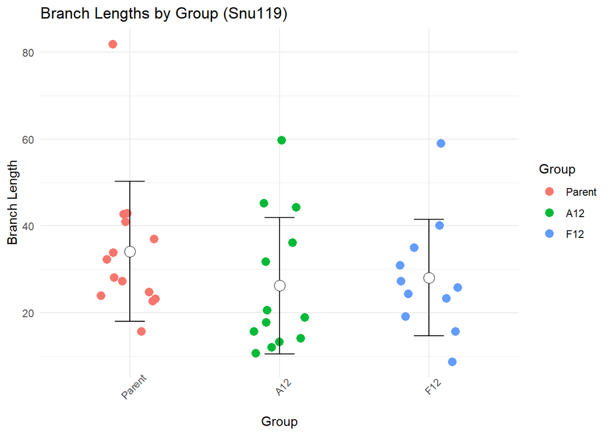

```r
# Scatter plot with jitter, error bars for SD, and mean points
ggplot(Snu119_branch_lengths, aes(x = Group, y = Branch_Length, color = Group)) +
  geom_jitter(width = 0.2, size = 3) +  # Jittered points
  # Error bars: Mean ± SD per group
  geom_errorbar(data = summary_stats_Snu119,
                aes(x = Group, y = mean_branch_length,
                    ymin = mean_branch_length - sd_branch_length,
                    ymax = mean_branch_length + sd_branch_length),
                width = 0.2, color = "black") +
  # Add mean points
  geom_point(data = summary_stats_Snu119, aes(x = Group, y = mean_branch_length),
             size = 4, shape = 21, fill = "white", color = "black") +
  theme_minimal() +
  labs(title = "Branch Lengths by Group (Snu119)",
       x = "Group",
       y = "Branch Length") +
  theme(axis.text.x = element_text(angle = 45))  # Rotate axis labels
```

LAQ 1: Part 2.1:  
Cancer genomes typically exhibit a variety of genomic alterations, which can be categorized as follows:

#1. Single nucleotide variants (SNVs)  
- When individual bases are altered, the resulting changes are known as point mutations. These mutations can significantly influence protein function or gene regulation.  
- Notable examples include activating mutations in oncogenes such as KRAS and BRAF, as well as inactivating mutations in tumor suppressor genes like TP53 and RB1.

#2. Insertions and deletions (Indels)  
- The addition or removal of specific small segments of DNA can lead to frameshift mutations or premature stop codons.  
- For instance, indels in genes such as BRCA1 or PTEN can impair their normal tumor-suppressing functions.

#3. Structural rearrangements  
- Large-scale genomic alterations include chromosomal translocations, inversions, and duplications.  
- An example is the Philadelphia chromosome, resulting from a translocation between chromosomes 9 and 22 (BCR-ABL), which is associated with chronic myeloid leukemia (CML).

#4. Copy number variations (CNVs)  
- These involve either amplifications or deletions of substantial chromosomal regions, impacting multiple genes.  
- A prominent example is the amplification of the HER2 gene in breast cancer, which facilitates tumor proliferation.

#5. Loss of heterozygosity (LOH)  
- This refers to the functional loss of a gene due to the loss of one of its alleles, particularly in tumor suppressor genes.  
- An example is LOH in TP53 observed in colon and breast cancers.

#6. Aneuploidy  
- Errors during chromosome segregation in cell division can result in abnormal numbers of chromosomes.  
- For example, additional copies of chromosome 8 are frequently observed in acute myeloid leukemia (AML).

#7. Microsatellite instability (MSI)  
- Deficiencies in mismatch repair mechanisms lead to mutations in repetitive DNA sequences known as microsatellites.  
- An example is the MSI-high phenotype found in colorectal and endometrial cancers.

#8. Epigenetic alterations  
- Changes in DNA methylation, histone modifications, and chromatin remodeling significantly influence gene expression.

LAQ 1: Part 2.2:  
Genomic Alterations Identifiable Through Single-cell Copy Number Estimation (AneuFinder):  
AneuFinder is primarily utilized for analyzing single-cell sequencing data and is adept at identifying alterations related to variations in DNA copy number, including:

# 1. Copy number variations (CNVs):

These are recognized as regions where the quantity of DNA has either increased (amplifications) or decreased (deletions).

# 2. Aneuploidy:

This condition is characterized by the gain or loss of entire chromosomes or chromosome arms.

# 3. Loss of heterozygosity (LOH):

## This phenomenon can be detected indirectly, although the specific allelic information may be somewhat restricted if it occurs alongside a reduction in copy number.

LAQ 1: Part 2.3:  
Genomic Alterations Not Detectable by AneuFinder and the Reasons:

1. Single nucleotide variants (SNVs):  
   These mutations occur at the base level and necessitate high-resolution sequencing techniques, such as whole-genome or targeted sequencing, which exceed the resolution capabilities of AneuFinder.
2. Insertions and deletions (small Indels):  
   Variations of a smaller scale are often overlooked due to the limited resolution of copy-number segmentation methods, which typically identify only larger segments (kilobase scale or above).
3. Chromosomal rearrangements (e.g., translocations and inversions):  
   Since AneuFinder primarily detects changes in segment copy number, it is unable to identify structural rearrangements that do not significantly alter copy number.
4. Microsatellite instability (MSI):  
   MSI consists of numerous subtle mutations within repetitive sequences, which are not detectable through analyses focused on copy number that lack the resolution for single-nucleotide changes.
5. Epigenetic alterations:  
   These modifications occur at the level of DNA or chromatin without altering the DNA sequence or copy number, rendering them completely undetectable by copy-number estimation tools such as AneuFinder.

**Part 6.1**  
**Most Dissimilar Clones in Each Population:**  
(This section compares clonal populations, not the parental population)

**A. Kuramochi Population (C8 v/s E10)**  
Most dissimilar clone: **Kuramochi_C8** (comparison made between clonal populations, not with the parental population)

*Reason*  
- Displays significant chromosomal amplifications (e.g., 7-10 somies), setting it apart from both the inferred ancestor (internal node) and other clones.  
- A high occurrence of whole-chromosome alterations, indicating substantial divergence.

**B. Snu119 Population (A12 v/s F12)**  
Most dissimilar clone: **Snu119_F12** (comparison made between clonal populations, not with the parental population)

*Reason*  
- Exhibits widespread trisomy and tetrasomy across almost all chromosomes compared to the parental line.  
- Displays marked chromosomal instability with clear aneuploidy patterns, distinguishing it from both other clones and the parental state.

**Part 6.2**  
**Key Changes Compared to Inferred Ancestor (Internal Node):**

**Whole Chromosome Gains:**  
- Shift from typical 2-somy or 3-somy to extreme amplifications, suggesting selection pressures favoring substantial genomic instability.

**Losses (Monosomy events):**  
- Some monosomic chromosomes are present, indicating selective loss for potential survival advantage.

**Recurrent Patterns of Gains:**  
- Trisomy and tetrasomy are dominant, marking a significant divergence from the inferred ancestor, which typically exhibits a 2-somy baseline.

**Losses Are Relatively Rare:**  
- Only a few monosomic chromosomes are observed, indicating strong selective pressure toward chromosomal gains rather than losses.